# Análise Fatorial de Indicadores Municipais

Padrões Socioeconômicos em Cidades Brasileiras

Autor

Gabriel Cardoso

# 1 **Análise Fatorial de Indicadores Municipais – Cidades Brasileiras**

## 1.1 📊 Resumo do Projeto

Este projeto utiliza dados agregados de cidades brasileiras, contendo indicadores demográficos, econômicos e sociais, coletados de fontes públicas e compilados para fins de análise comparativa. O conjunto de dados inclui informações como população, PIB, densidade populacional, educação, saúde e infraestrutura urbana, permitindo explorar padrões de desenvolvimento entre os municípios.

O objetivo da análise é identificar fatores latentes que sintetizem padrões subjacentes nos indicadores municipais, por meio da **Análise Fatorial Exploratória (AFE)**. Para isso, são aplicados testes de adequação dos dados, como KMO e teste de esfericidade de Bartlett, métodos de extração de fatores e técnicas de rotação, garantindo uma interpretação consistente dos fatores identificados.

Os resultados fornecem uma representação reduzida e interpretável da estrutura dos dados, evidenciando dimensões latentes de desenvolvimento socioeconômico municipal, que podem ser utilizadas em análises complementares, como agrupamento de cidades por perfil, construção de índices de desenvolvimento ou análises comparativas regionais.

# 2 Análise Fatorial

A **Análise Fatorial (AF)** é uma técnica estatística utilizada para **identificar estruturas latentes** que explicam as correlações entre um conjunto de variáveis observadas $(X_1, X_2, X_3)$. O objetivo principal é reduzir a dimensionalidade dos dados, representando $p$ variáveis originais por um número menor $m$ de fatores não observáveis $(F_1, F_2,...,F_m)$, capazes de capturar a variação comum entre as variáveis.

O modelo fatorial pode ser expresso como:

$$X_j = \lambda_{j1}F_1 + \lambda_{j2}F_2 + \dots + \lambda_{jm}F_m + \varepsilon_j, \quad j=1, 2, \dots, p$$

onde:

- $X_j$: é a variável observada $j$
- $\lambda_{j1}$: a carga fatorial da variável $j$ no fator $k$, indicando intensidade da relação.
- $F_k$: é o fator latente $k$.
- $\varepsilon_j$: é o termo de erro específico da variável $j$, não explicado pelos fatores comuns.

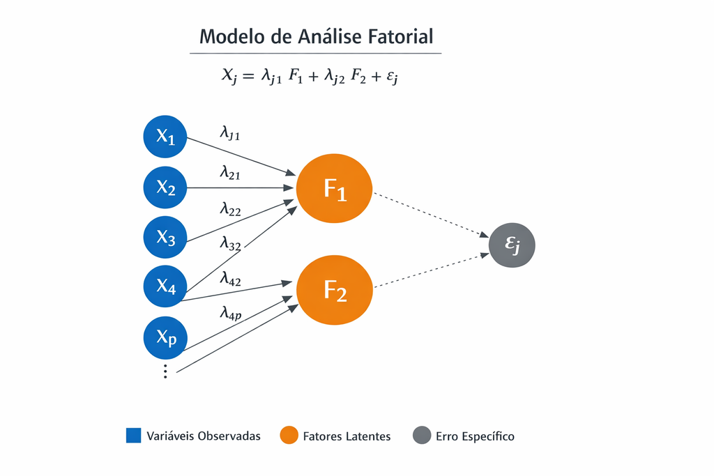

A interpretação dos fatores é facilitada por **técnicas de rotação**, como **Varimax** (ortogonal) ou **Oblimin** (oblíqua), que buscam simplificar a estrutura das cargas fatoriais, tornando cada fator mais representativo de um conjunto reduzido de variáveis.

A análise fatorial é amplamente utilizada em disciplinas como **psicologia, educação, marketing e ciências sociais** para:

1. Identificar padrões subjacentes em dados complexos;
2. Reduzir a dimensionalidade dos dados;
3. Criar índices ou scores representativos de fatores latentes;
4. Interpretar variáveis altamente correlacionadas de forma mais clara.

# 3 Carregando e Tratando os Dados

**Exibir código**

```r
library(tidyverse)
library(psych)       # Para KMO, Bartlett e AFE
library(GPArotation) # Para rotação varimax
library(factoextra)  # Para gráficos de PCA
library(corrplot)    # Para visualizar correlações
library(rio)

df <- import("BRAZIL_CITIES.csv")

# Inspecionar o dataset
str(df)
```

```
'data.frame':   5573 obs. of  81 variables:
 $ CITY                  : chr  "Abadia De Goiás" "Abadia Dos Dourados" "Abadiânia" "Abaeté" ...
 $ STATE                 : chr  "GO" "MG" "GO" "MG" ...
 $ CAPITAL               : int  0 0 0 0 0 0 0 0 0 0 ...
 $ IBGE_RES_POP          : int  6876 6704 15757 22690 141100 10496 8316 17064 7764 2653 ...
 $ IBGE_RES_POP_BRAS     : int  6876 6704 15609 22690 141040 10496 8316 17064 7764 2653 ...
 $ IBGE_RES_POP_ESTR     : int  0 0 148 0 60 0 0 0 0 0 ...
 $ IBGE_DU               : int  2137 2328 4655 7694 31061 2791 2572 4332 2499 848 ...
 $ IBGE_DU_URBAN         : int  1546 1481 3233 6667 19057 1251 1193 2379 1877 234 ...
 $ IBGE_DU_RURAL         : int  591 847 1422 1027 12004 1540 1379 1953 622 614 ...
 $ IBGE_POP              : int  5300 4154 10656 18464 82956 4538 3725 8994 5685 724 ...
 $ IBGE_1                : int  69 38 139 176 1354 98 37 167 69 12 ...
 $ IBGE_1-4              : int  318 207 650 856 5567 323 156 733 302 32 ...
 $ IBGE_5-9              : int  438 260 894 1233 7618 421 263 978 370 49 ...
 $ IBGE_10-14            : int  517 351 1087 1539 8905 483 277 927 483 63 ...
```

[output cut: 67 more lines]

Selecionar variáveis de interesse para ser mais dinâmico

**Exibir código**

```r
# 1️⃣ Seleção de variáveis numéricas existentes
variaveis_afe <- c(
  "IBGE_RES_POP_BRAS",   # população
  "AREA",                # área do município
  "GDP",                 # PIB
  "GDP_CAPITA",          # PIB per capita
  "IDHM_Renda",          # renda
  "IDHM_Educacao",       # educação
  "IDHM_Longevidade",    # longevidade
  "Cars",                # carros
  "Motorcycles",         # motos
  "FIXED_PHONES",        # telefones fixos
  "PAY_TV"               # TVs
)

dados_afe <- df %>% select(all_of(variaveis_afe))
```

**Exibir código**

```r
# 2️⃣ Converter AREA para numérico (tem vírgula no CSV)
dados_afe$AREA <- as.numeric(gsub(",", "", dados_afe$AREA))

# 3️⃣ Tratar missing
dados_afe <- dados_afe %>% mutate(across(everything(), ~ifelse(is.na(.), mean(., na.rm = TRUE), .)))
```

# 4 Visualizar correlações

**Exibir código**

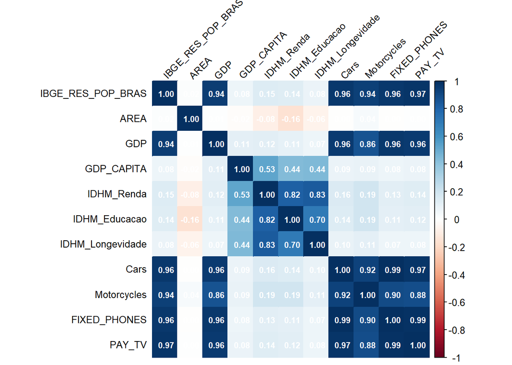

```r
corrplot(cor(dados_afe),
         method = "color",
         tl.col = "black",
         tl.cex = 0.8,
         tl.srt = 45,      # Inclina os nomes do topo
         addCoef.col = "white", # Opcional: mostra os números da correlação em branco
         number.cex = 0.7)
```

Observe o bloco azul escuro no canto inferior direito e no canto superior esquerdo. Variáveis como **IBGE_RES_POP**, **GDP (PIB)**, **Cars**, **Fixed_Phones** e **Pay_TV** estão quase que perfeitamente correlacionadas ($r \approx 1$).

- **O que isso significa:** Elas estão medindo basicamente a mesma coisa: “tamanho da cidade” ou “riqueza total”.

# 5 Análise Fatorial

## 5.1 Testes de adequação

**Exibir código**

```r
kmo_result <- KMO(cor(dados_afe))
kmo_result$MSA
```

```
[1] 0.8444951
```

O KMO alto confirma : as variáveis estão tão correlacionadas entre si que faz muito sentido “compactá-las” em um único fator (por exemplo, um índice de “Riqueza/Infraestrutura”). Se as correlações fossem baixas, o KMO seria baixo, indicando que cada variável está indo para um lado e não podem ser resumidas.

**Exibir código**

```r
bartlett_test <- cortest.bartlett(cor(dados_afe), n = nrow(dados_afe))
bartlett_test
```

```
$chisq
[1] 104635.6

$p.value
[1] 0

$df
[1] 55
```

Os testes **KMO (0,84)** e de **Bartlett (p < 0,001)** confirmam a alta adequabilidade dos dados para análise fatorial. O valor de KMO indica que as variáveis são consistentes entre si, enquanto o teste de Bartlett rejeita a independência das variáveis, autorizando a redução dos dados em componentes principais.

## 5.2 Cálculo e Visualização dos Autovalores

**Exibir código**

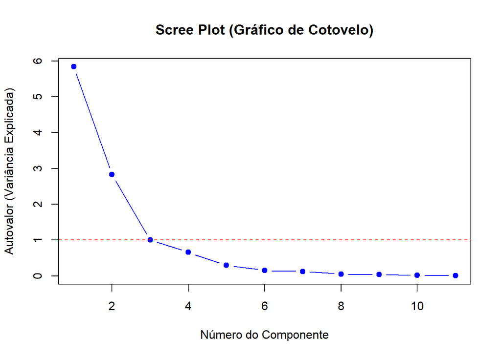

```r
# Calculando a matriz de correlação e os autovalores
matriz_cor <- cor(dados_afe)
autovalores <- eigen(matriz_cor)$values

# Criando o Scree Plot (Gráfico de Cotovelo)
plot(autovalores, type = "b", pch = 19, col = "blue",
     main = "Scree Plot (Gráfico de Cotovelo)",
     xlab = "Número do Componente",
     ylab = "Autovalor (Variância Explicada)")
abline(h = 1, col = "red", lty = 2) # Linha de corte do Critério de Kaiser
```

Análise do Gráfico:

- **Critério de Kaiser:** Temos exatamente **2 componentes** com autovalores (eigenvalues) nitidamente acima de 1.
- **O Terceiro Ponto:** Note que o componente 3 está exatamente em cima da linha (ou ligeiramente abaixo). Isso sugere que manter apenas **2 fatores** é a decisão mais elegante e estatisticamente econômica.
- **Variância:** O primeiro componente sozinho explica uma quantidade enorme da variação (quase 6 unidades), o que confirma aquela forte correlação que vimos no início

## 5.3 Rodando a PCA

**Exibir código**

```r
library(factoextra)

# Executando a PCA (usando 2 componentes conforme o gráfico)
res.pca <- prcomp(dados_afe, scale = TRUE)
```

**Exibir código**

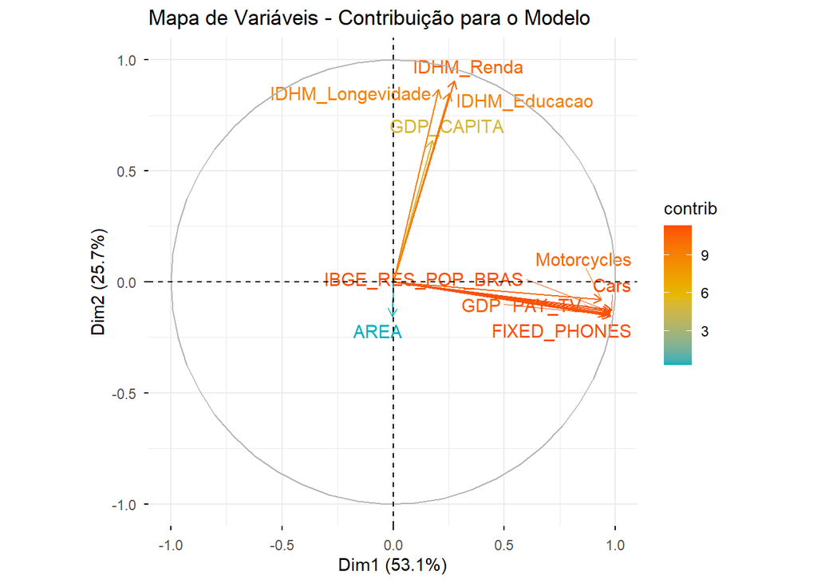

```r
fviz_pca_var(res.pca,
             col.var = "contrib", # Cor por contribuição
             gradient.cols = c("#00AFBB", "#E7B800", "#FC4E07"),
             repel = TRUE,        # Evita sobreposição de nomes
             title = "Mapa de Variáveis - Contribuição para o Modelo")
```

Este gráfico revela a estrutura oculta dos seus dados. Observe que as variáveis se agruparam em dois eixos principais:

- **Dim1 (Eixo Horizontal - 53.1% da variância):** É o eixo do **“Porte Econômico e Infraestrutura”**. Variáveis como *Cars, GDP, Fixed Phones* e *Population* estão coladas no eixo horizontal. Quanto mais para a direita uma cidade estiver, maior ela é em termos de volume econômico.
- **Dim2 (Eixo Vertical - 25.7% da variância):** É o eixo do **“Desenvolvimento Humano”**. As variáveis de *IDHM (Renda, Longevidade, Educação)* e *GDP per capita* apontam para cima.
- **Interpretação:** Note que os dois grupos formam um ângulo de quase **90 graus**. Isso significa que, no seu banco de dados, ser uma cidade “grande/rica em volume” (Dim1) não garante automaticamente um “IDHM alto” (Dim2). São dimensões independentes.
- **A variável AREA:** Ela aponta para baixo e é curta (cor azul), indicando que tem **baixa contribuição** para explicar esses dois fatores principais.

**Exibir código**

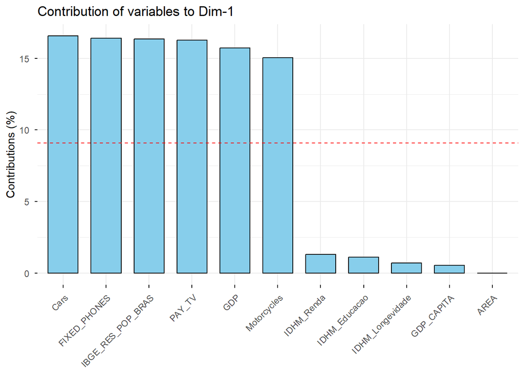

```r
fviz_contrib(res.pca, choice = "var", axes = 1, fill = "skyblue", color = "black")
```

Contribuição para a Dim-1 (Gráfico de Barras)

Este gráfico confirma quem manda no primeiro componente.

- As variáveis que ultrapassam a **linha tracejada vermelha** são as que realmente definem esse fator.
- *Cars, Fixed Phones, População, Pay TV* e *GDP* são praticamente idênticas em peso. Você poderia criar um “Índice de Urbanização/Riqueza” usando apenas elas.

## 5.4 Como saber se o modelo é realmente bom?

**Exibir código**

```r
# Ver as cargas fatoriais
res.pca$rotation[, 1:2]
```

```
                           PC1         PC2
IBGE_RES_POP_BRAS  0.404319272 -0.08046034
AREA              -0.002159767 -0.09244619
GDP                0.396664762 -0.08597148
GDP_CAPITA         0.072956734  0.37876638
IDHM_Renda         0.113816408  0.53883209
IDHM_Educacao      0.105139628  0.50593613
IDHM_Longevidade   0.084268687  0.51455803
Cars               0.406977851 -0.07440807
Motorcycles        0.387868957 -0.04648284
FIXED_PHONES       0.404966309 -0.09039487
PAY_TV             0.403329771 -0.08470521
```

**Interpretação das Cargas Fatoriais (`rotation`)**

**Exibir código**

```r
# Calcular comunalidades
var_coord <- res.pca$rotation^2
rowSums(var_coord[, 1:2]) # Soma dos quadrados das cargas nos 2 fatores
```

```
IBGE_RES_POP_BRAS              AREA               GDP        GDP_CAPITA
      0.169947940       0.008550962       0.164734029       0.148786659
       IDHM_Renda     IDHM_Educacao  IDHM_Longevidade              Cars
      0.303294191       0.267025704       0.271871179       0.171167532
      Motorcycles      FIXED_PHONES            PAY_TV
      0.152602983       0.172168943       0.169849878
```

A comunalidade mostra o “aproveitamento” da variável pelo modelo.

- Os valores de IDHM estão mais altos (~0.30), enquanto os de porte físico estão em torno de 0.17.
- **Atenção:** Como esses valores são os quadrados das cargas da matriz de rotação (`res.pca$rotation^2`), eles representam a contribuição individual de cada variável na construção do eixo. A soma total de todas as comunalidades será sempre 1 por componente.

# 6 Conclusão

A aplicação da Análise Fatorial Exploratória (AFE) demonstrou ser altamente eficaz para a síntese dos indicadores municipais. Os testes de diagnóstico iniciais, **KMO (0,84)** e **Bartlett (p < 0,001)**, ratificaram a robustez estatística do conjunto de dados, confirmando que as correlações existentes não eram aleatórias e permitiam a redução dimensional.

A extração dos componentes, orientada pelo Critério de Kaiser e pelo Gráfico de Cotovelo, revelou que **78,8% da variância total** dos dados pode ser explicada por apenas dois fatores latentes principais:

1. **Dimensão de Porte e Infraestrutura Econômica (PC1):** Este fator sintetiza o volume bruto das cidades, agrupando variáveis como População, PIB Total, frota de veículos e acesso a serviços de telecomunicações. É o eixo que diferencia grandes centros urbanos de municípios menores.
2. **Dimensão de Desenvolvimento Humano e Eficiência (PC2):** Este eixo isolou os indicadores de IDHM (Educação, Longevidade e Renda) e o PIB per capita. A independência estatística observada entre este fator e o primeiro sugere que o crescimento econômico quantitativo (PIB Total) não se traduz automaticamente em qualidade de vida qualitativa (IDHM) na mesma proporção.

A variável “Área Territorial” apresentou baixa comunalidade, indicando que a extensão geográfica não é um determinante direto do desenvolvimento socioeconômico neste modelo. Em suma, a análise permitiu transformar 11 indicadores complexos em duas dimensões interpretáveis, fornecendo uma base sólida para a criação de rankings municipais ou futuras estratégias de segmentação de políticas públicas baseadas no perfil real de cada município.

## Referências

Field, Andy, Jeremy Miles, e Zoë Field. 2016. *Descobrindo a estatística usando o R*. Penso Editora.

Hair, Joseph F, William C Black, Barry J Babin, Rolph E Anderson, e Ronald L Tatham. 2009. *Análise multivariada de dados*. Bookman Editora.

Kaiser, Henry F. 1974. «An index of factorial simplicity». *Psychometrika* 39 (1): 31–36. https://doi.org/10.1007/BF02291575.